# Intuit Quickbooks Upgrade

- Team-lead GitLab id:rsm-jcepela
- Group number:
- Group name:The Nameless
- Team member names: Qiuyi Lu, Xi Jiang, Zhengyu Jiang, Jake Cepela

```r
## loading the data (do NOT change the data)
intuit75k <- readr::read_rds("../data/intuit75k.rds")
```

## Question answers

### 1. Describe how you developed your predictive models, and discuss predictive performance for each model

### RFM

```r
number_bins <- 5

breakeven_rate <- ((1.41 / 60))

intuit_training <- intuit75k %>%
  filter(training == "1")

intuit_training$rec_iq <- xtile(intuit_training$last, number_bins)
intuit_training$freq_iq <- xtile(intuit_training$numords, number_bins, rev = T)
intuit_training$mon_iq <- xtile(intuit_training$dollars, number_bins, rev = T)
intuit_training$rfm_iq <- paste0(intuit_training$rec_iq, intuit_training$freq_iq, intuit_training$mon_iq)

intuit_training$rec_sq <- xtile(intuit_training$last, number_bins)
intuit_training <- intuit_training %>%
  group_by(rec_sq) %>%
  mutate(freq_sq = xtile(numords, number_bins, rev = T)) %>%
  ungroup()
intuit_training <- intuit_training %>%
  group_by(rec_sq, freq_sq) %>%
  mutate(mon_sq = xtile(dollars, number_bins, rev = T)) %>%
  ungroup()
intuit_training$rfm_sq <- paste0(intuit_training$rec_sq, intuit_training$freq_sq, intuit_training$mon_sq)

intuit_training <- intuit_training %>%
  group_by(rfm_iq) %>%
  mutate(iq_rate = mean(res1 == "Yes"), iq_rate_lb = (mean(res1 == "Yes") - 1.64 * seprop(res1 == "Yes")), iq_rate_ub = (mean(res1 == "Yes") + 1.64 * seprop(res1 == "Yes"))) %>%
  mutate(send_iq = iq_rate > breakeven_rate, send_iq_lb = iq_rate_lb > breakeven_rate, send_iq_ub = iq_rate_ub > breakeven_rate) %>%
  ungroup()

intuit_training <- intuit_training %>%
  group_by(rfm_sq) %>%
  mutate(sq_rate = mean(res1 == "Yes"), sq_rate_lb = (mean(res1 == "Yes") - 1.64 * seprop(res1 == "Yes")), sq_rate_ub = (mean(res1 == "Yes") + 1.64 * seprop(res1 == "Yes"))) %>%
  mutate(send_sq = sq_rate > breakeven_rate, send_sq_lb = sq_rate_lb > breakeven_rate, send_sq_ub = sq_rate_ub > breakeven_rate) %>%
  ungroup()
```

```r
intuit75k_test <- intuit75k %>%
  filter(intuit75k$training == "0")

intuit75k_test$rec_iq <- xtile(intuit75k_test$last, number_bins)
intuit75k_test$freq_iq <- xtile(intuit75k_test$numords, number_bins, rev = T)
intuit75k_test$mon_iq <- xtile(intuit75k_test$dollars, number_bins, rev = T)
intuit75k_test$rfm_iq <- paste0(intuit75k_test$rec_iq, intuit75k_test$freq_iq, intuit75k_test$mon_iq)

intuit75k_test$rec_sq <- xtile(intuit75k_test$last, number_bins)
intuit75k_test <- intuit75k_test %>%
  group_by(rec_sq) %>%
  mutate(freq_sq = xtile(numords, number_bins, rev = T)) %>%
  ungroup()
intuit75k_test <- intuit75k_test %>%
  group_by(rec_sq, freq_sq) %>%
  mutate(mon_sq = xtile(dollars, number_bins, rev = T)) %>%
  ungroup()
intuit75k_test$rfm_sq <- paste0(intuit75k_test$rec_sq, intuit75k_test$freq_sq, intuit75k_test$mon_sq)

intuit75k_test <- intuit75k_test %>%
  left_join(
    intuit_training %>%
      select(rfm_iq, iq_rate, send_iq, iq_rate_lb, send_iq_lb, iq_rate_ub, send_iq_ub) %>%
      unique()
  )

intuit75k_test <- intuit75k_test %>%
  left_join(intuit_training %>%
    select(rfm_sq, sq_rate, send_sq, sq_rate_lb, send_sq_lb, sq_rate_ub, send_sq_ub) %>%
    unique())
```

# Profit Calculation

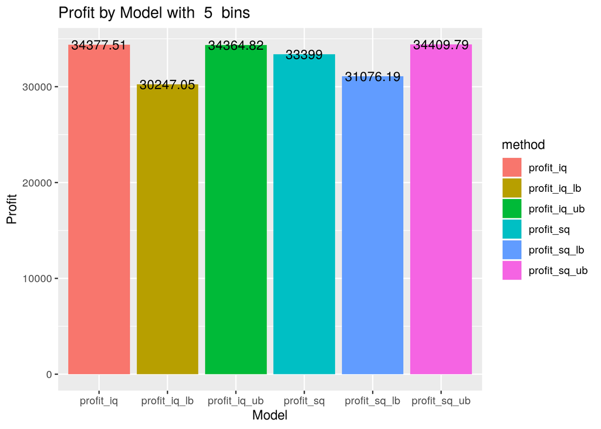

```r
profit_iq <- data.frame(method = "profit_iq", profit = (sum(intuit75k_test$res1 == "Yes" & intuit75k_test$send_iq == T) * 60 - sum(intuit75k_test$send_iq == T) * 1.41))

profit_iq_lb <- data.frame(method = "profit_iq_lb", profit = sum(intuit75k_test$res1 == "Yes" & intuit75k_test$send_iq_lb == T) * 60 - sum(intuit75k_test$send_iq_lb == T) * 1.41)
profit_iq_ub <- data.frame(method = "profit_iq_ub", profit = sum(intuit75k_test$res1 == "Yes" & intuit75k_test$send_iq_ub == T) * 60 - sum(intuit75k_test$send_iq_ub == T) * 1.41)

profit_sq <- data.frame(method = "profit_sq", profit = sum(intuit75k_test$res1 == "Yes" & intuit75k_test$send_sq == T) * 60 - sum(intuit75k_test$send_sq == T) * 1.41)
profit_sq_lb <- data.frame(method = "profit_sq_lb", profit = sum(intuit75k_test$res1 == "Yes" & intuit75k_test$send_sq_lb == T) * 60 - sum(intuit75k_test$send_sq_lb == T) * 1.41)
profit_sq_ub <- data.frame(method = "profit_sq_ub", profit = sum(intuit75k_test$res1 == "Yes" & intuit75k_test$send_sq_ub == T) * 60 - sum(intuit75k_test$send_sq_ub == T) * 1.41)

profit <- data.frame(rbind(profit_iq, profit_iq_lb, profit_iq_ub, profit_sq, profit_sq_lb, profit_sq_ub))

profit %>%
  ggplot(aes(x = method, y = profit, fill = method, label = profit)) +
  geom_bar(stat = "identity") +
  geom_text() +
  labs(x = "Model", y = "Profit", title = paste("Profit by Model with ", number_bins, " bins"))
```

# Accuracy of Model

```r
tp <- sum(intuit75k_test$send_sq_ub == T & intuit75k_test$res1 == "Yes")
fp <- sum(intuit75k_test$send_sq_ub == T & intuit75k_test$res1 == "No")
tn <- sum(intuit75k_test$send_sq_ub == F & intuit75k_test$res1 == "No")
fn <- sum(intuit75k_test$send_sq_ub == F & intuit75k_test$res1 == "Yes")

accuracy <- (tp + tn) / (tp + tn + fp + fn)

print(paste0("Accuracy for the sq ub model ", accuracy))
```

```
[1] "Accuracy for the sq ub model 0.0836444444444444"
```

# ROME

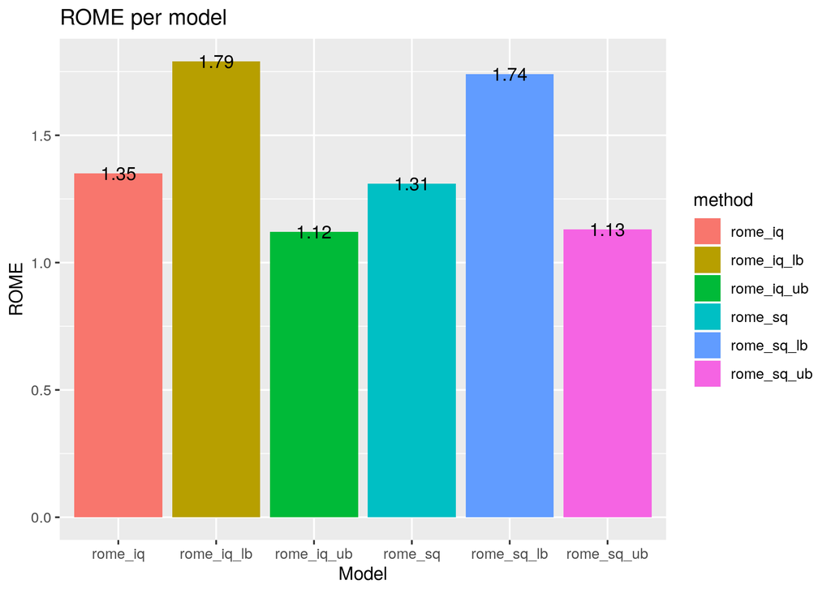

```r
rome_iq <- data.frame("method" = "rome_iq", "ROME" = (profit_iq[[1, 2]] / (sum(intuit75k_test$send_sq == T) * 1.41)))
rome_iq_lb <- data.frame("method" = "rome_iq_lb", "ROME" = profit_iq_lb[[1, 2]] / (sum(intuit75k_test$send_iq_lb == T) * 1.41))
rome_iq_ub <- data.frame("method" = "rome_iq_ub", "ROME" = profit_iq_ub[[1, 2]] / (sum(intuit75k_test$send_iq_ub) * 1.41))

rome_sq <- data.frame("method" = "rome_sq", "ROME" = profit_sq[[1, 2]] / (sum(intuit75k_test$send_sq == T) * 1.41))
rome_sq_lb <- data.frame("method" = "rome_sq_lb", "ROME" = profit_sq_lb[[1, 2]] / (sum(intuit75k_test$send_sq_lb == T) * 1.41))
rome_sq_ub <- data.frame("method" = "rome_sq_ub", "ROME" = profit_sq_ub[[1, 2]] / (sum(intuit75k_test$send_sq_ub == T) * 1.41))

rome <- rbind(rome_iq, rome_iq_lb, rome_iq_ub, rome_sq, rome_sq_lb, rome_sq_ub)
rome$ROME <- round(rome$ROME, 2)

rome %>%
  ggplot(aes(x = method, y = ROME, fill = method, label = ROME)) +
  geom_bar(stat = "identity") +
  geom_text() +
  labs(x = "Model", y = "ROME", title = "ROME per model")
```

#### To analyze how we could best target customers, we explored three different models: RFM, Logistic Regression, and Neural Network.

#### We started with the RFM model, looking both into independent and sequential binning.

#### Further, we broke those down with their breakeven rates and looked at the mean of the response rate, the upper bound of the response rate, and the lower bound of response rate using the standard error to account for variation.

#### We ran the model using different number of bins, with a low of four to a high of nine, to see if the profit would change. Comparing profit, we found that the model with seven bins came out to be the best. Using seven bins, however, had many bins with NA values as there were none in the training for it to predict off. We determined that using 5 bins and having values in all bins was more important, as the gain in profit was modest. Calculating the profit from these models, we found that the RFM model using sequential binning and the upper bound was the most profitable, at $34,409.79 (see exhibit 1).

#### The lowest profit was with independent binning and the lower bound threshold, which was $30,247.05(exhibit 1).

#### This reverse was true for the ROME, with the lowest profit having the highest ROME. The focus for this exercise was on profit so this was not a concern.

### Logistic Regression

```r
##load data
intuit75k_total =read_csv("../intuit75k_withstate.csv")  #we created a new state column by matching the zip code with 50 states of the united states. See python jupyter notebook how we match the zip code with state.

saveRDS(intuit75k_total,"intuit75k_total.rds")

intuit75k=readRDS("intuit75k_total.rds")
intuit75k=intuit75k %>% mutate(label=ifelse(res1=='Yes',1,0)) %>% mutate(recency=last,frequency=numords,monetary=dollars,log_dollars=log(dollars),std_numords=standardize(numords),std_last =standardize(last),std_dollars=standardize(dollars),std_sincepurch=standardize(sincepurch))
margin=60
cost=1.41
breakeven_response=1.41/60
average_response_rate=sum(intuit75k$label)/nrow(intuit75k)
intuit75k_train=intuit75k%>% filter(training==1)
intuit75k_test=intuit75k%>% filter(training==0)
```

#### define a profit,ROME function

```r
calculate_prof_ROME=function(dataf,colname,coltext){

TP=dataf %>%filter (pred_click==TRUE,label==1)
pred_true=sum(dataf$pred_click)
revenue=nrow(TP)*margin
totalcost=cost*sum(pred_true)
exp_profit=revenue-totalcost
exp_ROME=exp_profit/totalcost

result=data.frame(expected_profit=exp_profit,expected_ROME=round(exp_ROME,2),auc=ModelMetrics::auc(dataf$label,dataf$pred_click),model=coltext)

return(result)
}
```

#### logistic regression models

```r
## basic lg probability
cut_off=1.41/60

#using 50 states and standardize numeric variables:

f1 = label ~ zip_state+sex+ bizflag+ std_numords+std_last+std_dollars+std_sincepurch+owntaxprod+version1+upgraded

glm.fits=glm(formula=f1,data=intuit75k_train,family=binomial)
summary(glm.fits)
```

```
Call:
glm(formula = f1, family = binomial, data = intuit75k_train)

Deviance Residuals:
    Min       1Q   Median       3Q      Max
-1.4618  -0.3224  -0.2390  -0.1796   3.2325

Coefficients:
                Estimate Std. Error z value             Pr(>|z|)
(Intercept)    -3.583924   0.286163 -12.524 < 0.0000000000000002 ***
zip_stateAL     0.058658   0.342080   0.171              0.86385
zip_stateAR    -0.710623   0.501413  -1.417              0.15641
zip_stateAZ    -0.454546   0.332039  -1.369              0.17101
zip_stateCA    -0.156234   0.284592  -0.549              0.58302
zip_stateCO    -0.162959   0.316349  -0.515              0.60647
zip_stateCT    -0.219108   0.343032  -0.639              0.52299
zip_stateDC    -0.299783   0.457813  -0.655              0.51259
zip_stateDE     0.228884   0.433391   0.528              0.59741
zip_stateFL    -0.510810   0.301728  -1.693              0.09047 .
zip_stateGA     0.014065   0.308379   0.046              0.96362
zip_stateHI    -0.201892   0.367073  -0.550              0.58232
zip_stateIA    -0.949386   0.475200  -1.998              0.04573 *
zip_stateID    -0.034399   0.409805  -0.084              0.93310
zip_stateIL    -0.428566   0.308060  -1.391              0.16417
zip_stateIN    -0.212152   0.339390  -0.625              0.53191
zip_stateKS    -0.020596   0.356344  -0.058              0.95391
zip_stateKY    -0.472948   0.407167  -1.162              0.24542
zip_stateLA     0.050370   0.348947   0.144              0.88522
zip_stateMA     1.690216   0.283832   5.955         0.0000000026 ***
zip_stateMD    -0.366700   0.318874  -1.150              0.25015
zip_stateME    -0.383432   0.479116  -0.800              0.42354
zip_stateMI    -0.198874   0.313617  -0.634              0.52600
zip_stateMN     0.058789   0.321819   0.183              0.85505
zip_stateMO     0.246177   0.315980   0.779              0.43593
zip_stateMS    -0.682886   0.534647  -1.277              0.20151
zip_stateMT    -0.166015   0.459812  -0.361              0.71806
zip_stateNC    -0.371229   0.323595  -1.147              0.25130
zip_stateND    -0.503965   0.656321  -0.768              0.44257
zip_stateNE    -0.251551   0.419565  -0.600              0.54880
zip_stateNH    -0.414469   0.441997  -0.938              0.34839
```

[output cut: 27 more lines]

```
std_dollars     0.086508   0.022149   3.906         0.0000939546 ***
std_sincepurch  0.017616   0.039997   0.440              0.65962
owntaxprod      0.307144   0.102661   2.992              0.00277 **
version1        0.755940   0.087002   8.689 < 0.0000000000000002 ***
upgraded        0.968740   0.085826  11.287 < 0.0000000000000002 ***
---
Signif. codes:  0 '***' 0.001 '**' 0.01 '*' 0.05 '.' 0.1 ' ' 1

(Dispersion parameter for binomial family taken to be 1)

    Null deviance: 20090  on 52499  degrees of freedom
Residual deviance: 17809  on 52437  degrees of freedom
AIC: 17935

Number of Fisher Scoring iterations: 6
```

```r
click_logit=predict(glm.fits, newdata = intuit75k_test, type = "response")

test_data=intuit75k_test%>%
  mutate(pred_click=ifelse(click_logit > cut_off,TRUE,FALSE))

logit_basic=calculate_prof_ROME(test_data,pred_click,"logit_basic")
```

```r
#using bins:

f2 = label ~ zip_bins+sex+ bizflag+ std_numords+std_last+std_dollars+std_sincepurch+owntaxprod+version1+upgraded

glm.fits=glm(formula=f2,data=intuit75k_train,family=binomial)

click_logit=predict(glm.fits, newdata = intuit75k_test, type = "response")
click_logit2=click_logit

test_data=intuit75k_test%>%
  mutate(pred_click=ifelse(click_logit2 > cut_off,TRUE,FALSE))

logit_using_bins=calculate_prof_ROME(test_data,pred_click,"logit_using_bins")
```

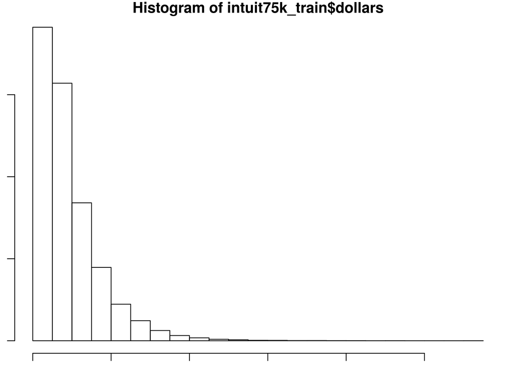

```r
#using log dollar:

par(mar=c(1,1,1,1))
hist(intuit75k_train$dollars) ##right skewed,using log to turn it into normally distributed.
```

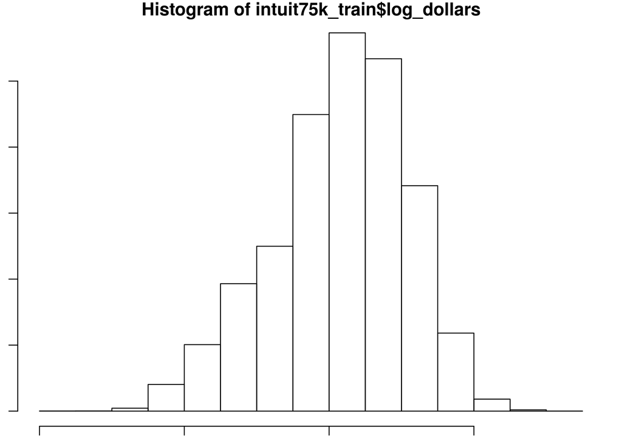

```r
hist(intuit75k_train$log_dollars)
```

```r
f3 = label ~ zip_state+sex+ bizflag+ std_numords+std_last+standardize(log_dollars)+std_sincepurch+owntaxprod+version1+upgraded

glm.fits=glm(formula=f3,data=intuit75k_train,family=binomial)

click_logit=predict(glm.fits, newdata = intuit75k_test, type = "response")

test_data=intuit75k_test%>%
  mutate(pred_click=ifelse(click_logit > cut_off,TRUE,FALSE))


logit_logdollar=calculate_prof_ROME(test_data,pred_click,"logit_logdollar") # result of standardize(log(dollar)) is not better than the standardized(dollar)
```

```r
#using interactions of variables:

f_interaction = label ~ zip_state+sex+ zip_state*sex+bizflag+ std_numords+std_last+standardize(log_dollars)+std_sincepurch+owntaxprod+version1+upgraded

glm.fits=glm(formula=f_interaction,data=intuit75k_train,family=binomial)

click_logit=predict(glm.fits, newdata = intuit75k_test, type = "response")

test_data=intuit75k_test%>%
  mutate(pred_click=ifelse(click_logit > cut_off,TRUE,FALSE))


logit_interaction=calculate_prof_ROME(test_data,pred_click,"logit_interaction")
```

```r
set.seed(1234)
# Dumy code categorical predictor variables
x <- model.matrix(f1, intuit75k_train)[,-1]
# Convert the outcome (class) to a numerical variable
y <- intuit75k_train$label

cv.lasso <- cv.glmnet(x, y, alpha = 1, family = "binomial")

#coef(cv.lasso, cv.lasso$lambda.min)
#coef(cv.lasso, cv.lasso$lambda.1se)
```

```r
#using lasso

model <- glmnet(x, y, alpha = 1, family = "binomial",
                lambda = cv.lasso$lambda.min)

# Make predictions on the test data
x.test <- model.matrix(f1, intuit75k_test)[,-1]
probabilities <- model %>% predict(newx = x.test,type="response")

test_data=intuit75k_test%>%
  mutate(pred_click=ifelse(probabilities> cut_off,TRUE,FALSE))

logit_base_lasso_min=calculate_prof_ROME(test_data,pred_click,"logit_base_lasso_min")



#lambda.1se
model_1se <- glmnet(x, y, alpha = 1, family = "binomial",
                lambda = cv.lasso$lambda.1se)

# Make predictions on the test data
x.test <- model.matrix(f1, intuit75k_test)[,-1]
probabilities <- model_1se %>% predict(newx = x.test,type="response")

test_data=intuit75k_test%>%
  mutate(pred_click=ifelse(probabilities> cut_off,TRUE,FALSE))

logit_base_lasso1se=calculate_prof_ROME(test_data,pred_click,"logit_base_lasso1se")
```

```r
## You should do this with logistic regression as well and compare the results to the lower bound estimates you get directly from radiant.model::logistic or pyrsm.predict_conf_int

result_conf= radiant.model::logistic(intuit75k_train,rvar='res1',evar=c('zip_state','sex', 'bizflag','std_numords','std_last','std_dollars','std_sincepurch','owntaxprod','version1','upgraded'),lev='Yes')

conf_logit=predict(result_conf, pred_data = intuit75k_test, conf_lev = 0.9, se = TRUE)

intuit75k_test=intuit75k_test%>% mutate(click_logit_lb=conf_logit$`5%`,click_logit_ub=conf_logit$`95%`)

test_data=intuit75k_test%>%
  mutate(pred_click=ifelse(click_logit_lb> cut_off,TRUE,FALSE))

logit_base_lb=calculate_prof_ROME(test_data,pred_click,"logit_base_lb")


test_data=intuit75k_test%>%
  mutate(pred_click=ifelse(click_logit_ub> cut_off,TRUE,FALSE))

logit_base_ub=calculate_prof_ROME(test_data,pred_click,"logit_base_ub")
```

Because it took too long time to run bootstrap. We didn’t run it when we knit. Please see the code in the RMD file.

#### discuss predictive performance for each model : real profit,rome

```r
compare_lg= rbind(logit_basic,logit_base_lasso_min,logit_base_lasso1se,logit_base_lb,logit_base_ub,logit_logdollar,logit_interaction) %>% arrange(desc(expected_profit))
compare_lg
```

```
  expected_profit expected_ROME       auc                model
1        38289.54          1.91 0.6313675          logit_basic
2        38267.07          1.80 0.6206412 logit_base_lasso_min
3        38149.80          1.90 0.6300870      logit_logdollar
4        38073.69          1.94 0.6334849    logit_interaction
5        37509.48          1.57 0.5915195        logit_base_ub
6        37345.11          2.32 0.6576490        logit_base_lb
7        37016.01          1.39 0.5636688  logit_base_lasso1se
```

#### Further, we investigated the binning of zip codes and determined we wanted those to be more granular.

#### To do this we took all zip codes and found out which state each was in and created a new column. Further, we standardized numeric variables, specifically numords, last, dollars, and sincepurch. With the new attributes calculated, we tried a few different variations of combinations to find which model performed the best.

#### Our model started simple and progressively became more complex. We added interactions(zip_state*sex), tried taking the log of dollars to account for the right skew, tried using the non-standardized data, used lasso, bootstrap, lowerbound and upperbound of the probability.

#### Running different combinations of these, our best model came to use state, sex, the business flag, standardized number of orders, standardized dollars, standardized time since original Quickbooks purchase, standardized time since last order from Intuit Direct, if the owner purchased tax software, if the customer has version 1, and if the customer upgraded to version 2.

#### Looking to profit as a measure of performance, this model outperformed all other logistic regressions that we ran. The profit for this model was $38,289.54 with a ROME of 1.91.

### Deep learning

Because it took too long time to run cv.nn. We didn’t run it when we knit. Please see the code in the RMD file and the output picture. decay=0.4,size=2 yielded the highest auc.

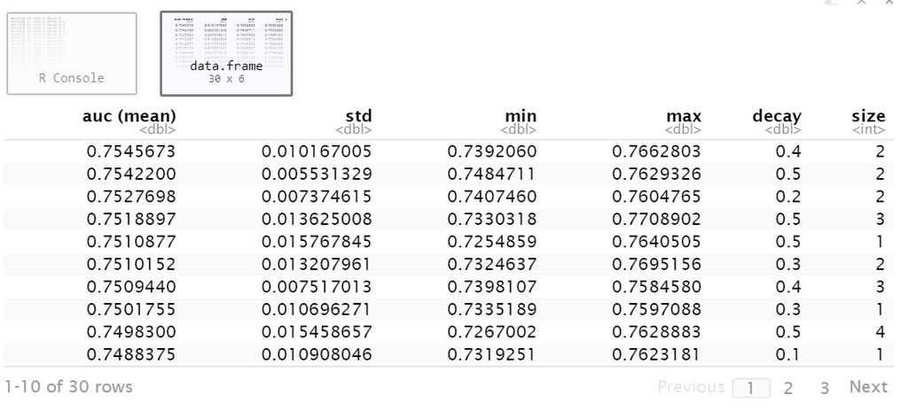

result of cross validation of NN

```r
## Using decay=0.4,size=2

nnmodel <- nn(
  intuit75k_train,
  rvar = "res1",
  evar = c(
    "sex", "bizflag","version1", "owntaxprod", "upgraded","zip_state","std_numords","std_last","std_dollars","std_sincepurch"
  ),
  lev = "Yes",
  size=2,
  decay=0.4,
  seed=1234
)

pred_pro=predict(nnmodel, pred_data = intuit75k_test)

test_data_nn=intuit75k_test%>%
  mutate(click_logit=pred_pro$Prediction,pred_click=ifelse(click_logit > cut_off,TRUE,FALSE))

pred_pro_train=predict(nnmodel, pred_data = intuit75k_train)
train_data_nn=intuit75k_train%>%
  mutate(click_logit=pred_pro_train$Prediction,pred_click=ifelse(click_logit > cut_off,TRUE,FALSE))


deep_learning_r=calculate_prof_ROME(test_data_nn,pred_click,"deep_learning")
deep_learning_r
```

```
  expected_profit expected_ROME       auc         model
1        37894.56           2.1 0.6455294 deep_learning
```

Because it took too long time to run bootstrap. We didn’t run it when we knit. Please see the code in the RMD file. We save the result and load it in the next chunk.

```r
# Next, calculate the 5th percentile of the predictions to use as the lower bound on the estimated probability.

total_nn_100=readRDS("../data/total_nn_100.rds")

total_nn_100_sd= total_nn_100 %>% select(-id)
temp=as.matrix(total_nn_100_sd)
fifth=rowQuantiles(temp,probs = 0.05)
sd=rowSds(temp)

total_nn_100_sd= total_nn_100_sd %>% mutate(mean=rowSums(.)/100,sd=sd,lb_sd=mean-1.64*sd,lb_5percentile=fifth)
total_nn_100_sd=cbind(id=intuit75k_test$id,total_nn_100_sd) #lower bound probability of deep learning

test_data=intuit75k_test%>%
  mutate(click_logit=total_nn_100_sd$lb_sd,pred_click=ifelse(click_logit > cut_off,TRUE,FALSE))
deep_learning_r_lb_sd=calculate_prof_ROME(test_data,pred_click,"deep_learning_r_lb")

test_data=intuit75k_test%>%
  mutate(click_logit=total_nn_100_sd$lb_5percentile,pred_click=ifelse(click_logit > cut_off,TRUE,FALSE))

deep_learning_r_lb_5th=calculate_prof_ROME(test_data,pred_click,"deep_learning_r_lb_5th")
deep_learning_r_lb_5th
```

```
  expected_profit expected_ROME       auc                  model
1         36503.7          2.75 0.6752838 deep_learning_r_lb_5th
```

#### deep learning without lowerbound is better in profit. But still lower than logistic regression model.

#### Satisfied with the performance of our logistic, we went to use a neural network in both R and Python. We used the model that we found worked best during our exploration of the logistic regression as our base model. Here, we once again used bootstrap on our model in order to get the lower bound. We used decay and size in a range and used cross validation to find the best size and decay for our model. Once again, we looked to profit to measure performance.

#### The expected profit for a deep learning model came to be $37,894.56, which is lower than the logistic model.

### 2. How did you compare and evaluate different models?

#### performance comparing,choose a model. What criteria did you use to decide which customers should receive the wave-2 mailing?

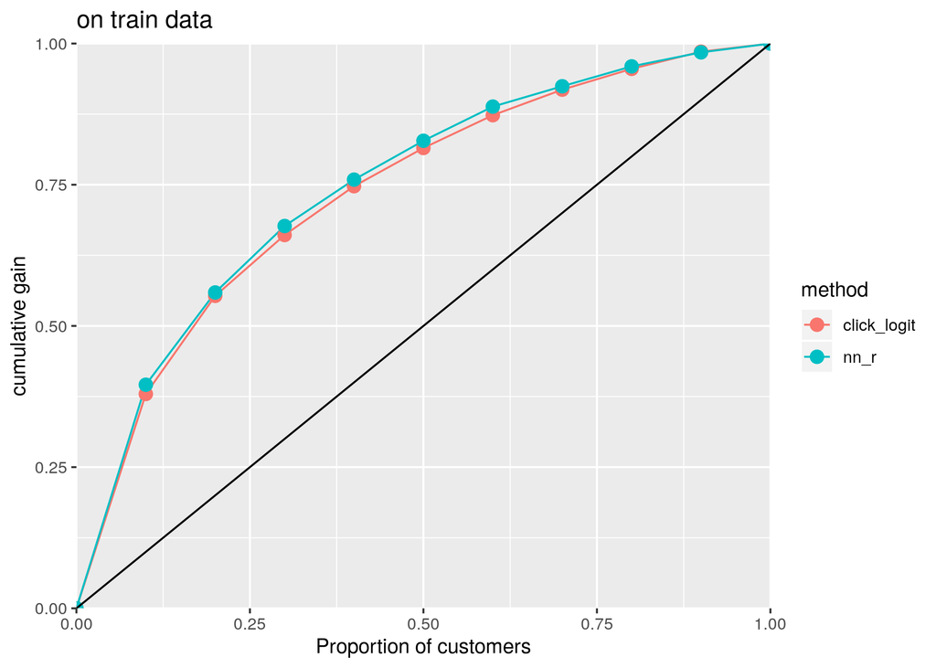

```r
## Compare gains plot of logistic and deep learning model.

intuit75k=intuit75k %>% mutate(label=ifelse(res1=='Yes',1,0)) %>% mutate(recency=last,frequency=numords,monetary=dollars,log_dollars=log(dollars),std_numords=standardize(numords),std_last =standardize(last),std_dollars=standardize(dollars),std_sincepurch=standardize(sincepurch))
intuit75k_train=intuit75k%>% filter(training==1)
intuit75k_test=intuit75k%>% filter(training==0)

## logit cumulative lift gains(on train and test)

#define a chart function
gain_chart=function(df,colname,colcontent){
df = df%>% mutate(dec_logit=xtile(!! colname,10,rev=TRUE))
dec_df_logit= df %>% group_by(dec_logit) %>% summarize(number_mails=n(),number_click=sum(label),click_through_rate=number_click/number_mails)
dec_df_logit_gain= dec_df_logit %>% mutate(cum_number_mail=cumsum(number_mails),
                                      cum_number_click=cumsum(number_click),
                                      gains=number_click/sum(number_click),
                                      cum_gains=cum_number_click/sum(number_click)
                                      )

dec_df_logit_gain2=dec_df_logit_gain%>% rbind(rep(0,8)) %>% select('dec_logit','cum_gains') %>% mutate(method=colcontent)

return(dec_df_logit_gain2)
}

#lg on train and test data
f1 = label ~ zip_state+sex+ bizflag+ std_numords+std_last+std_dollars+std_sincepurch+owntaxprod+version1+upgraded

glm.fits=glm(formula=f1,data=intuit75k_train,family=binomial)

click_logit=predict(glm.fits, newdata = intuit75k_test, type = "response")

test_data=intuit75k_test%>%
  mutate(click_logit=click_logit,pred_click=ifelse(click_logit > cut_off,TRUE,FALSE))

train_data=intuit75k_train%>%
  mutate(click_logit=predict(glm.fits, newdata = intuit75k_train, type = "response"),pred_click=ifelse(click_logit > cut_off,TRUE,FALSE))


train_lg_gain=gain_chart(train_data,quo(click_logit),"click_logit")
test_lg_gain=gain_chart(test_data,quo(click_logit),"click_logit")

## nn's gain on train and test data:
train_nn_gain=gain_chart(train_data_nn,quo(click_logit),"nn_r")
test_nn_gain=gain_chart(test_data_nn,quo(click_logit),"nn_r")


##compare table
compare_gains_train=rbind(train_lg_gain,train_nn_gain)
compare_gains_test=rbind(test_lg_gain,test_nn_gain)

plot_train=compare_gains_train%>%ggplot(aes(x=dec_logit/10,y=cum_gains,group=method,color=method))+geom_line()+geom_point(size=3)+labs(x='Proportion of customers',y='cumulative gain',title='on train data')+scale_y_continuous(breaks=seq(0,1,0.25),expand = c(0, 0),limits = c(0,1)) +scale_x_continuous(breaks=seq(0,1,0.25),expand = c(0, 0),limits = c(0,1)) + geom_abline(intercept=0,slope=1)

plot_train
```

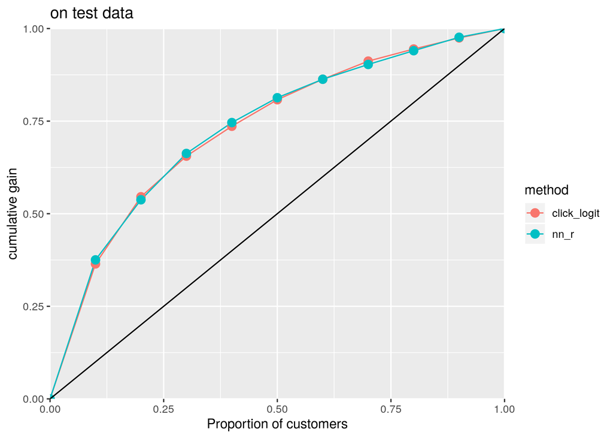

```r
plot_test=compare_gains_test%>%ggplot(aes(x=dec_logit/10,y=cum_gains,group=method,color=method))+geom_line()+geom_point(size=3)+labs(x='Proportion of customers',y='cumulative gain',title='on test data')+scale_y_continuous(breaks=seq(0,1,0.25),expand = c(0, 0),limits = c(0,1)) +scale_x_continuous(breaks=seq(0,1,0.25),expand = c(0, 0),limits = c(0,1)) + geom_abline(intercept=0,slope=1)

plot_test
```

#### Comparing all the models, we looked to see the profit that would have been generated on the test set had the model been used. Out of them, our best logistic regression model outperformed the RFM Model and the Neural Net model we created.

#### We also compared gains plot of logistic and deep learning model on both train and test data. There are no large difference between the two models. So finnally, we chose the logistic regression model because it yielded the highest profit.

### 3. If you created new variables to include in the model, please describe these as well

#### zip_state(see python notebook),interaction variable(sex*zip_state)

### 4. What criteria did you use to decide which customers should receive the wave-2 mailing?

#### using the logit model to predict the name list:

```r
wave2_mailist=intuit75k %>% filter (training=="0")

click_logit=predict(glm.fits, newdata = wave2_mailist, type = "response")

wave2_mail=wave2_mailist%>%
  mutate(click_logit=click_logit,mailto_wave2=ifelse(click_logit*0.5 > cut_off,TRUE,FALSE))  %>% select(id,mailto_wave2)


write.csv(wave2_mail,"../data/Qiuyi_Xi_Zhengyu_Jake_TheNameless.csv",row.names = FALSE)
```

#### Our criteria for determining which customer should receive wave-2 mailing was based on using the best model, regarding profit, in order to predict who would respond to the mailer. This took into consideration that the response rate for the second wave would be estimated at 50% of the response rate for the first wave. The companies that we would send to in the file provided were a result of using our best logistic regression to predict who to send to.

### 5. How much profit do you anticipate from the wave-2 mailing?

```r
# first, calculate how many predicted true in 801,821-38,487=763,334 people

total_number=801821-38487
wave2_mailist=intuit75k %>% filter(training==0,res1=='No')

click_logit=predict(glm.fits, newdata = wave2_mailist, type = "response")

wave2_mail=wave2_mailist%>%
  mutate(click_logit=click_logit,pred_click=ifelse(click_logit*0.5 > cut_off,TRUE,FALSE))

pred_true_wave2_mailist=mean(wave2_mail$pred_click)
send_number=pred_true_wave2_mailist*total_number

#total cost
total_cost=1.41*send_number


#profit

f1 = label ~ zip_state+sex+ bizflag+ std_numords+std_last+std_dollars+std_sincepurch+owntaxprod+version1+upgraded

glm.fits=glm(formula=f1,data=intuit75k_train,family=binomial)

click_logit=predict(glm.fits, newdata = intuit75k_test, type = "response")

test_data=intuit75k_test%>%
  mutate(pred_click=ifelse(click_logit > cut_off,TRUE,FALSE))

pred_true=sum(test_data$pred_click)
TP=test_data %>%filter (pred_click==TRUE,label==1)
TPrate=nrow(TP)/pred_true

TP=TPrate*send_number

pred_revenue=TP*margin
exp_profit=pred_revenue-total_cost
exp_ROME=exp_profit/total_cost

print(paste0("The expected profit is ",exp_profit))
```

```
[1] "The expected profit is 602216.250413978"
```

#### To calculate our expected profit, we first removed the businesses that responded to the original mailer from the total population we could send to. We then predicted whether or not someone in the test set would be sent to during the wave 1 mailing. We took the response rate for that mailing (those that responded of the ones that we sent to), to use as the response rate for the next wave. Our model doubled the breakeven threshold already to account for the decrease in response during the second wave. We removed the 38,487 from the 801,821 to get 763,334 possible businesses to send to. We took the proportion of total 763,334 that we would send to and multiplied that by the response rate that we calculated in order to predict the profit we anticipate. For our cost, we took all of the businesses we predicted we would send to times the $1.41. Our estimated profit of the businesses left is $602,216.30.

### 6. What did you learn about the type of businesses that are likely to upgrade?

#### Looking at the businesses that ended up responding, we are able to summarize a few key points. The more orders a company made, how soon their last purchase was, how many much the company has spent in the last 36 months, if they owned the tax product, if they were still on version 1, and if they upgraded strongly determine whether or not they will upgrade to version 3.

#### Essentially, if they had a newer product or weren’t a consistent customer, they were less likely to upgrade to version 3. This is intuitive, as customers often have brand loyalty and don’t upgrade frequently if the product they have isn’t too out of date. The most prominent factor we found was with whether or not they had previously upgraded, which suggests that if they had upgraded once they would again. Next, the companies that were in version 1 were more likely to upgrade. In tandem, these suggest that the companies that were likely to upgrade were previous customers of the product and have used Quickbooks since version one.